# Assignment 2: Spatial Analysis and Visualization

Healthcare Access and Equity in Pennsylvania

Author

Jinyang Xu

Published

October 14, 2025

## Assignment Overview

**Learning Objectives:** - Apply spatial operations to answer policy-relevant research questions - Integrate census demographic data with spatial analysis - Create publication-quality visualizations and maps - Work with spatial data from multiple sources - Communicate findings effectively for policy audiences

## Part 1: Healthcare Access for Vulnerable Populations

### Research Question

**Which Pennsylvania counties have the highest proportion of vulnerable populations (elderly + low-income) living far from hospitals?**

Your analysis should identify counties that should be priorities for healthcare investment and policy intervention.

### Required Analysis Steps

Complete the following analysis, documenting each step with code and brief explanations:

#### Step 1: Data Collection (5 points)

Load the required spatial data: - Pennsylvania county boundaries - Pennsylvania hospitals (from lecture data) - Pennsylvania census tracts

**Your Task:**

[figure not shown]

```r
# Load required packages
library(tidyverse)
library(dplyr)
library(knitr)
library(tidycensus)
library(sf)
library(tigris)
library(scales)
library(patchwork)
library(here)
library(units)

# Load spatial data
census_api_key("fef2af5588030f3fd4b474bd111e0d63a7ec2837")

pa_county <- st_read("data/Pennsylvania_County_Boundaries.shp")
pa_hos <- st_read("data/hospitals.geojson")
pa_tracts <- tracts(state = "PA", year = 2020, class = "sf")
# Check that all data loaded correctly

ggplot(data = pa_county) +
  geom_sf(fill = "lightblue", color = "white", size = 0.2) +
  labs(title = "Census Tracts in Philadelphia County, PA (2020)",
       caption = "Source: US Census Bureau TIGER/Line") +
  theme_minimal()
```

[figure not shown]

```r
ggplot(data = pa_tracts) +
  geom_sf(fill = "lightblue", color = "white", size = 0.2) +
  labs(title = "Census Tracts in Philadelphia County, PA (2020)",
       caption = "Source: US Census Bureau TIGER/Line") +
  theme_minimal()
```

```r
st_crs(pa_hos)
```

```
Coordinate Reference System:
  User input: WGS 84
  wkt:
GEOGCRS["WGS 84",
    DATUM["World Geodetic System 1984",
        ELLIPSOID["WGS 84",6378137,298.257223563,
            LENGTHUNIT["metre",1]]],
    PRIMEM["Greenwich",0,
        ANGLEUNIT["degree",0.0174532925199433]],
    CS[ellipsoidal,2],
        AXIS["geodetic latitude (Lat)",north,
            ORDER[1],
            ANGLEUNIT["degree",0.0174532925199433]],
        AXIS["geodetic longitude (Lon)",east,
            ORDER[2],
            ANGLEUNIT["degree",0.0174532925199433]],
    ID["EPSG",4326]]
```

```r
st_crs(pa_county)
```

```
Coordinate Reference System:
  User input: WGS 84 / Pseudo-Mercator
  wkt:
PROJCRS["WGS 84 / Pseudo-Mercator",
    BASEGEOGCRS["WGS 84",
        ENSEMBLE["World Geodetic System 1984 ensemble",
            MEMBER["World Geodetic System 1984 (Transit)"],
            MEMBER["World Geodetic System 1984 (G730)"],
            MEMBER["World Geodetic System 1984 (G873)"],
            MEMBER["World Geodetic System 1984 (G1150)"],
            MEMBER["World Geodetic System 1984 (G1674)"],
            MEMBER["World Geodetic System 1984 (G1762)"],
            MEMBER["World Geodetic System 1984 (G2139)"],
            MEMBER["World Geodetic System 1984 (G2296)"],
            ELLIPSOID["WGS 84",6378137,298.257223563,
                LENGTHUNIT["metre",1]],
            ENSEMBLEACCURACY[2.0]],
        PRIMEM["Greenwich",0,
            ANGLEUNIT["degree",0.0174532925199433]],
        ID["EPSG",4326]],
    CONVERSION["Popular Visualisation Pseudo-Mercator",
        METHOD["Popular Visualisation Pseudo Mercator",
            ID["EPSG",1024]],
        PARAMETER["Latitude of natural origin",0,
            ANGLEUNIT["degree",0.0174532925199433],
            ID["EPSG",8801]],
        PARAMETER["Longitude of natural origin",0,
            ANGLEUNIT["degree",0.0174532925199433],
            ID["EPSG",8802]],
        PARAMETER["False easting",0,
            LENGTHUNIT["metre",1],
            ID["EPSG",8806]],
        PARAMETER["False northing",0,
            LENGTHUNIT["metre",1],
            ID["EPSG",8807]]],
    CS[Cartesian,2],
        AXIS["easting (X)",east,
            ORDER[1],
            LENGTHUNIT["metre",1]],
        AXIS["northing (Y)",north,
            ORDER[2],
            LENGTHUNIT["metre",1]],
    USAGE[
        SCOPE["Web mapping and visualisation."],
        AREA["World between 85.06°S and 85.06°N."],
        BBOX[-85.06,-180,85.06,180]],
    ID["EPSG",3857]]
```

```r
st_crs(pa_tracts)
```

```
Coordinate Reference System:
  User input: NAD83
  wkt:
GEOGCRS["NAD83",
    DATUM["North American Datum 1983",
        ELLIPSOID["GRS 1980",6378137,298.257222101,
            LENGTHUNIT["metre",1]]],
    PRIMEM["Greenwich",0,
        ANGLEUNIT["degree",0.0174532925199433]],
    CS[ellipsoidal,2],
        AXIS["latitude",north,
            ORDER[1],
            ANGLEUNIT["degree",0.0174532925199433]],
        AXIS["longitude",east,
            ORDER[2],
            ANGLEUNIT["degree",0.0174532925199433]],
    ID["EPSG",4269]]
```

**Questions to answer:** - How many hospitals are in your dataset? 223 rows in the data.

#### Step 2: Get Demographic Data

Use `tidycensus` to download tract-level demographic data for Pennsylvania.

**Required variables:** - Total population - Median household income - Population 65 years and over (you may need to sum multiple age categories)

**Your Task:**

```r
# Get demographic data from ACS
pa_pop <- get_acs(
  geography = "tract",
  variables = "B01003_001",
  state = "PA",
  year = 2022,
  geometry = FALSE
)

pa_income <- get_acs(
  geography = "tract",
  variables = "B19013_001",
  state = "PA",
  year = 2022,
  geometry = FALSE
)
age65_vars <- c(
  "B01001_020", "B01001_021", "B01001_022", "B01001_023", "B01001_024", "B01001_025", # Male 65+
  "B01001_044", "B01001_045", "B01001_046", "B01001_047", "B01001_048", "B01001_049"  # Female 65+
)

pa_age65 <- get_acs(
  geography = "tract",
  variables = age65_vars,
  state = "PA",
  year = 2022,
  geometry = FALSE
) %>%
  group_by(GEOID) %>%
  summarize(age65_total = sum(estimate))



# Join to tract boundaries

pa_demographics <- pa_tracts %>%
  left_join(pa_pop %>% select(GEOID, total_pop = estimate), by = "GEOID") %>%
  left_join(pa_income %>% select(GEOID, median_income = estimate), by = "GEOID") %>%
  left_join(pa_age65, by = "GEOID") %>%
  mutate(pct_65plus = 100 * age65_total / total_pop)
pa_demographics
```

```
Simple feature collection with 3446 features and 16 fields
Geometry type: MULTIPOLYGON
Dimension:     XY
Bounding box:  xmin: -80.51985 ymin: 39.7198 xmax: -74.68956 ymax: 42.51607
Geodetic CRS:  NAD83
First 10 features:
   STATEFP COUNTYFP TRACTCE       GEOID    NAME             NAMELSAD MTFCC
1       42      095  017703 42095017703  177.03  Census Tract 177.03 G5020
2       42      101  012204 42101012204  122.04  Census Tract 122.04 G5020
3       42      129  804300 42129804300    8043    Census Tract 8043 G5020
4       42      129  804801 42129804801 8048.01 Census Tract 8048.01 G5020
5       42      129  805200 42129805200    8052    Census Tract 8052 G5020
6       42      101  012203 42101012203  122.03  Census Tract 122.03 G5020
7       42      101  013602 42101013602  136.02  Census Tract 136.02 G5020
8       42      101  034502 42101034502  345.02  Census Tract 345.02 G5020
```

[output cut: 24 more lines]

```r
sum(is.na(pa_demographics$median_income))
```

```
[1] 63
```

```r
median(pa_demographics$median_income, na.rm = TRUE)
```

```
[1] 70188
```

**Questions to answer:** - What year of ACS data are you using?

2022 - How many tracts have missing income data?

63 - What is the median income across all PA census tracts?

## $70188

#### Step 3: Define Vulnerable Populations

Identify census tracts with vulnerable populations based on TWO criteria: 1. Low median household income (choose an appropriate threshold) 2. Significant elderly population (choose an appropriate threshold)

**Your Task:**

```r
# Filter for vulnerable tracts based on your criteria

# bottom 25%
low_income_threshold <- quantile(pa_demographics$median_income, 0.25, na.rm = TRUE)
# top 25%
high_elderly_threshold <- quantile(pa_demographics$pct_65plus, 0.75, na.rm = TRUE)


pa_vulnerable <- pa_demographics %>%
  mutate(
    vulnerable_income = median_income < low_income_threshold,
    vulnerable_age = pct_65plus > high_elderly_threshold,
    vulnerable = vulnerable_income & vulnerable_age
  )

vulnerable_count <- sum(pa_vulnerable$vulnerable, na.rm = TRUE)
total_tracts <- nrow(pa_vulnerable)
vulnerable_pct <- 100 * vulnerable_count / total_tracts

vulnerable_count
```

```
[1] 165
```

```r
vulnerable_pct
```

```
[1] 4.78816
```

**Questions to answer:** - What income threshold did you choose and why?

I chose the bottom 25% of tracts based on median household income, which corresponds to tracts with income below approximately $54,000. This threshold identifies communities that are relatively low-income compared to the rest of Pennsylvania. - What elderly population threshold did you choose and why?

Elderly population threshold: I selected the top 25% of tracts by percentage of residents aged 65 and over, representing tracts where more than about 20.5% of residents are elderly. This captures areas with a significantly aging population that may face accessibility and healthcare challenges. - How many tracts meet your vulnerability criteria?

165 - What percentage of PA census tracts are considered vulnerable by your definition?

## 4.78816%

#### Step 4: Calculate Distance to Hospitals

For each vulnerable tract, calculate the distance to the nearest hospital.

**Your Task:**

```r
# Transform to appropriate projected CRS
pa_vul <- pa_vulnerable %>%
  filter(vulnerable)
pa_vul_proj <- st_transform(pa_vul, 26917)
pa_hos_proj <- st_transform(pa_hos, 26917)

# Calculate distance from each tract centroid to nearest hospital

vul_center <- pa_vul_proj %>%
  st_centroid()

vul_center <- vul_center %>%
  mutate(
    nearest_idx = st_nearest_feature(., pa_hos_proj)
  ) %>%
  mutate(
    dist_mi = st_distance(., pa_hos_proj[nearest_idx, ], by_element = TRUE) %>%
      set_units("mi") %>%
      drop_units()
  )

summary_stats <- vul_center %>%
  summarize(
    avg_dist_mi = mean(dist_mi, na.rm = TRUE),
    max_dist_mi = max(dist_mi, na.rm = TRUE),
    over15_count = sum(dist_mi > 15, na.rm = TRUE),
    total_vul = n()
  ) %>%
  mutate(
    pct_over15 = 100 * over15_count / total_vul
  )

summary_stats %>%
  st_drop_geometry() %>%
  kable(
    caption = "Table. Hospital Access Among Vulnerable Census Tracts in Pennsylvania",
    digits = 2,
    align = "lrrrr"
  )
```

Table. Hospital Access Among Vulnerable Census Tracts in Pennsylvania

| avg_dist_mi | max_dist_mi | over15_count | total_vul | pct_over15 |
| --- | --- | --- | --- | --- |
| 4.75 | 19.18 | 9 | 165 | 5.45 |

**Requirements:** - Use an appropriate projected coordinate system for Pennsylvania - Calculate distances in miles - Explain why you chose your projection

**Questions to answer:** - What is the average distance to the nearest hospital for vulnerable tracts?

4.75miles - What is the maximum distance?

#### Step 5: Identify Underserved Areas

Define “underserved” as vulnerable tracts that are more than 15 miles from the nearest hospital.

**Your Task:**

```r
# Create underserved variable

vul_center <- vul_center %>%
  mutate(
    underserved= (as.numeric(dist_mi> 15))
  )

under_count= sum(vul_center$underserved)
vul_pct= under_count/ nrow(vul_center)
under_count
```

```
[1] 9
```

```r
vul_pct
```

```
[1] 0.05454545
```

**Questions to answer:** - How many tracts are underserved?

9 - What percentage of vulnerable tracts are underserved?

5.45% - Does this surprise you? Why or why not?

Yes — I didn’t expect any tracts to be this far from a hospital. This suggests that while most of Pennsylvania’s vulnerable areas have reasonable healthcare access, a few rural or remote tracts still face significant geographic barriers to medical services.

#### Step 6: Aggregate to County Level

Use spatial joins and aggregation to calculate county-level statistics about vulnerable populations and hospital access.

**Your Task:**

```r
pa_county <- st_transform(pa_county, crs=26917)
vul_center<- st_transform(vul_center, crs=st_crs(pa_county))

st_county <- st_join(
  pa_county,
  vul_center,
  join  = st_contains,
  left  = TRUE                # keep all counties
)

# Aggregate statistics by county

agg_county <- st_county %>%
  group_by(COUNTY_NAM) %>%
  summarise(
    vul_count= sum(vulnerable),
    und_count= sum(underserved),
    pct_vul_underserved = 100 * sum(vulnerable & underserved) / sum(vulnerable),
    avg_dist_vulnerable = mean(dist_mi[vulnerable], na.rm = TRUE),
    vul_pop = sum(total_pop[vulnerable]),
    und_pop = sum(total_pop[underserved])
  )

agg_county <- agg_county %>%
  mutate(across(where(is.numeric), ~replace(., is.na(.), 0)))
agg_county
```

```
Simple feature collection with 67 features and 7 fields
Geometry type: MULTIPOLYGON
Dimension:     XY
Bounding box:  xmin: 539820.7 ymin: 4396937 xmax: 1034915 ymax: 4680425
Projected CRS: NAD83 / UTM zone 17N
# A tibble: 67 × 8
   COUNTY_NAM vul_count und_count pct_vul_underserved avg_dist_vulnerable
 * <chr>          <dbl>     <dbl>               <dbl>               <dbl>
 1 ADAMS              0         0                   0                0
 2 ALLEGHENY         22         0                   0                2.84
 3 ARMSTRONG          1         0                   0               10.0
 4 BEAVER             5         0                   0                2.83
 5 BEDFORD            2         0                   0                7.97
 6 BERKS              0         0                   0                0
 7 BLAIR              3         0                   0                3.07
 8 BRADFORD           1         1                 100               16.7
 9 BUCKS              0         0                   0                0
10 BUTLER             0         0                   0                0
# ℹ 57 more rows
# ℹ 3 more variables: vul_pop <dbl>, und_pop <dbl>, geometry <MULTIPOLYGON [m]>
```

```r
# --- Step 6: Top 5 counties with highest % of underserved vulnerable tracts ---
top5_underserved <- agg_county %>%
  st_drop_geometry() %>%
  arrange(desc(pct_vul_underserved)) %>%
  select(COUNTY_NAM, pct_vul_underserved, vul_count, und_count) %>%
  head(5)

# --- Step 7: Top 5 counties with largest vulnerable population far from hospitals ---
top5_vulpop_far <- agg_county %>%
  st_drop_geometry() %>%
  arrange(desc(und_pop)) %>%
  select(COUNTY_NAM, und_pop, vul_pop, avg_dist_vulnerable) %>%
  head(5)

# --- Step 8: Display results ---
top5_underserved
```

```
# A tibble: 5 × 4
  COUNTY_NAM pct_vul_underserved vul_count und_count
  <chr>                    <dbl>     <dbl>     <dbl>
1 BRADFORD                   100         1         1
2 FOREST                     100         1         1
3 JUNIATA                    100         1         1
4 MONROE                     100         1         1
5 SULLIVAN                   100         1         1
```

```r
top5_vulpop_far
```

```
# A tibble: 5 × 4
  COUNTY_NAM und_pop vul_pop avg_dist_vulnerable
  <chr>        <dbl>   <dbl>               <dbl>
1 BRADFORD      5466    5466               16.7
2 CLEARFIELD    5285   13056               11.4
3 DAUPHIN       4392    8410                9.96
4 POTTER        4257    9062                9.55
5 CRAWFORD      2842    9072                8.35
```

**Required county-level statistics:** - Number of vulnerable tracts - Number of underserved tracts  
- Percentage of vulnerable tracts that are underserved - Average distance to nearest hospital for vulnerable tracts - Total vulnerable population

**Questions to answer:** - Which 5 counties have the highest percentage of underserved vulnerable tracts?

BRADFORD FOREST JUNIATA MONROE SULLIVAN - Which counties have the most vulnerable people living far from hospitals?

BRADFORD CLEARFIELD DAUPHIN POTTER CRAWFORD - Are there any patterns in where underserved counties are located?

These are typically larger rural counties where population is dispersed and hospitals are sparse. Urban counties (like Philadelphia or Allegheny) rarely appear because of dense hospital networks.

#### Step 7: Create Summary Table

Create a professional table showing the top 10 priority counties for healthcare investment.

**Your Task:**

```r
# Create and format priority counties table
agg_county <- agg_county %>%
  mutate(
    z_vul_pop     = scales::rescale(vul_pop),       # vulnerability
    z_underserved = scales::rescale(pct_vul_underserved), # service deficit
    z_distance    = scales::rescale(avg_dist_vulnerable), # accessibility
    priority_score = 0.25*z_vul_pop + 0.1*z_underserved + 0.65*z_distance
  )

priority_table <- agg_county %>%
  arrange(desc(priority_score)) %>%
  slice(1:10) %>%
  transmute(
    `County` = COUNTY_NAM,
    `Priority Score` = round(priority_score*100, 2),
    `Vulnerable Population` = comma(vul_pop),
    `Avg. Dist. to Hospital (mi)` = round(avg_dist_vulnerable, 2),
    `Underserved (%)` = percent(pct_vul_underserved / 100, accuracy = 0.01),
    `Vulnerable Tracts` = vul_count,
    `Underserved Tracts` = und_count,
  )

priority_table %>%
  st_drop_geometry() %>%
  kable(
    caption = "***Table 1. Top 10 Priority Counties for Healthcare Investment in Pennsylvania***",
    align = "lrrrrrr",
    format = "pipe"
  )
```

*Table 1. Top 10 Priority Counties for Healthcare Investment in Pennsylvania*

| County | Priority Score | Vulnerable Population | Avg. Dist. to Hospital (mi) | Underserved (%) | Vulnerable Tracts | Underserved Tracts |
| --- | --- | --- | --- | --- | --- | --- |
| FOREST | 76.09 | 2,701 | 18.12 | 100.00% | 1 | 1 |
| MONROE | 74.10 | 1,299 | 17.73 | 100.00% | 1 | 1 |
| BRADFORD | 72.03 | 5,466 | 16.68 | 100.00% | 1 | 1 |
| SULLIVAN | 71.10 | 918 | 16.93 | 100.00% | 1 | 1 |
| JUNIATA | 67.81 | 1,782 | 15.92 | 100.00% | 1 | 1 |
| HUNTINGDON | 51.77 | 2,558 | 14.15 | 0.00% | 1 | 0 |
| CLEARFIELD | 48.54 | 13,056 | 11.37 | 25.00% | 4 | 1 |
| DAUPHIN | 44.11 | 8,410 | 9.96 | 50.00% | 2 | 1 |
| NORTHUMBERLAND | 43.73 | 9,087 | 11.17 | 0.00% | 4 | 0 |
| POTTER | 41.26 | 9,062 | 9.55 | 33.33% | 3 | 1 |

**Requirements:** - Use `knitr::kable()` or similar for formatting - Include descriptive column names - Format numbers appropriately (commas for population, percentages, etc.) - Add an informative caption - Sort by priority (you decide the metric)

## Part 2: Comprehensive Visualization

Using the skills from Week 3 (Data Visualization), create publication-quality maps and charts.

### Map 1: County-Level Choropleth

Create a choropleth map showing healthcare access challenges at the county level.

**Your Task:**

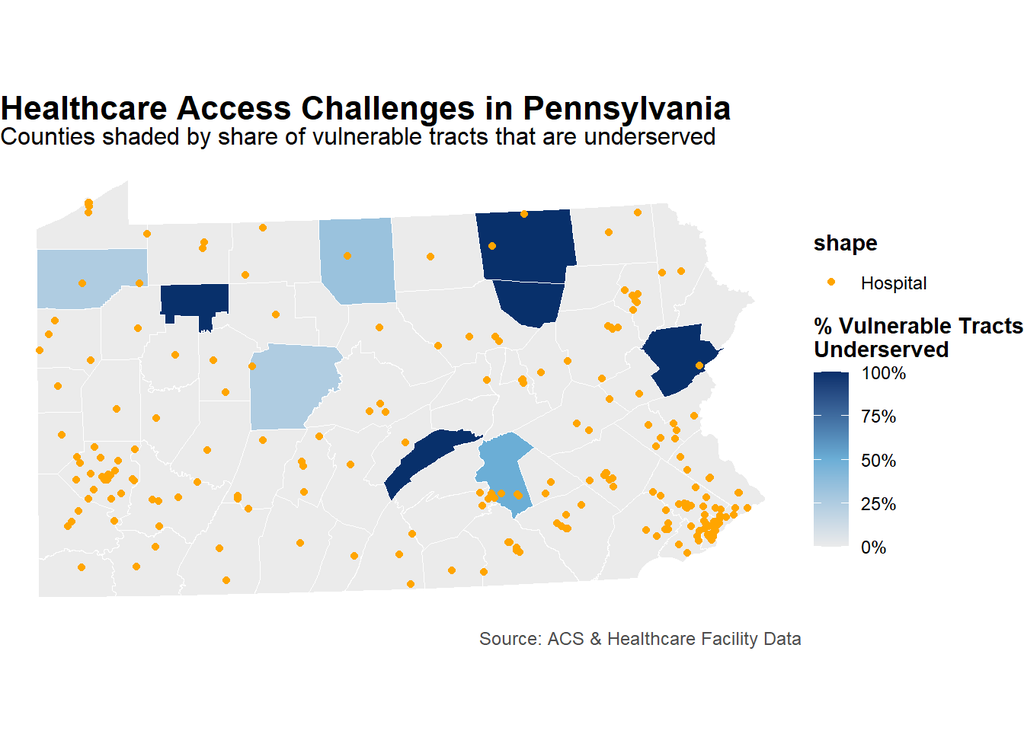

```r
pa_county_plot <- st_transform(agg_county, crs = 26917)     # NAD83 / UTM zone 17N
pa_hospitals_plot <- st_transform(pa_hos_proj, crs = st_crs(pa_county_plot))


ggplot() +
  geom_sf(
    data = pa_county_plot,
    aes(fill = pct_vul_underserved),
    color = "white",
    size = 0.2
  ) +

  #Hospital points
  geom_sf(
    data = pa_hospitals_plot,
    aes(shape = "Hospital"),
    color="orange",
    size = 1.5,
    stroke = 0.4
  ) +

  scale_fill_gradientn(
    colors = c("grey92", "#6baed6", "#08306b"),
    name = "% Vulnerable Tracts\nUnderserved",
    labels = label_percent(scale = 1, accuracy = 1)
  ) +

  labs(
    title = "Healthcare Access Challenges in Pennsylvania",
    subtitle = "Counties shaded by share of vulnerable tracts that are underserved",
    caption = "Source: ACS & Healthcare Facility Data"
  ) +

  theme_void(base_size = 12) +
  theme(
    plot.title = element_text(face = "bold", size = 16),
    plot.subtitle = element_text(size = 12, margin = margin(b = 5)),
    plot.caption = element_text(size = 9, color = "gray30"),
    legend.title = element_text(size = 11, face = "bold"),
    legend.text = element_text(size = 9),
    legend.position = "right"
  )
```

**Requirements:** - Fill counties by percentage of vulnerable tracts that are underserved - Include hospital locations as points - Use an appropriate color scheme - Include clear title, subtitle, and caption - Use `theme_void()` or similar clean theme - Add a legend with formatted labels

### Map 2: Detailed Vulnerability Map

Create a map highlighting underserved vulnerable tracts.

**Your Task:**

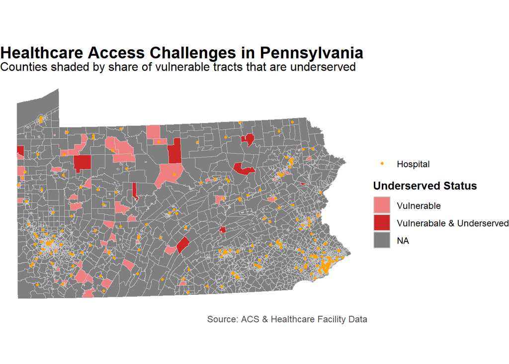

```r
pa_tracts <- st_transform(pa_tracts, crs=26917)
vul_center <- st_transform(vul_center, crs=26917)
vul_tracts_poly <- st_join(pa_tracts, vul_center, join= st_contains)

# Create detailed tract-level map
ggplot() +
  geom_sf(
    data = vul_tracts_poly,
    aes(fill = as.factor(underserved)),
    color = "grey80",
    size = 0.5
  ) +

  geom_sf(
    data = pa_hospitals_plot,
    aes(shape = "Hospital", color = "Hospital"),  # 👈 通过 aes() 进入图例
    size = 1.2,
    stroke = 0.4
  ) +

 scale_fill_manual(
    name = "Underserved Status",
    values = c("0" = "lightcoral", "1" = "firebrick3"),  # 👈 定义 0/1/NA 颜色
    labels = c("0"="Vulnerable", "1" = "Vulnerabale & Underserved" ),
 )+

  scale_color_manual(
    name = "",
    values = c("Hospital" = "orange")
  ) +
  scale_shape_manual(
    name = "",
    values = c("Hospital" = 16)
  ) +

  labs(
    title = "Healthcare Access Challenges in Pennsylvania",
    subtitle = "Counties shaded by share of vulnerable tracts that are underserved",
    caption = "Source: ACS & Healthcare Facility Data"
  ) +

  theme_void(base_size = 12) +
  theme(
    plot.title = element_text(face = "bold", size = 16),
    plot.subtitle = element_text(size = 12, margin = margin(b = 5)),
    plot.caption = element_text(size = 9, color = "gray30"),
    legend.title = element_text(size = 11, face = "bold"),
    legend.text = element_text(size = 9),
    legend.position = "right"
  )
```

**Requirements:** - Show underserved vulnerable tracts in a contrasting color - Include county boundaries for context - Show hospital locations - Use appropriate visual hierarchy (what should stand out?) - Include informative title and subtitle

### Chart: Distribution Analysis

Create a visualization showing the distribution of distances to hospitals for vulnerable populations.

**Your Task:**

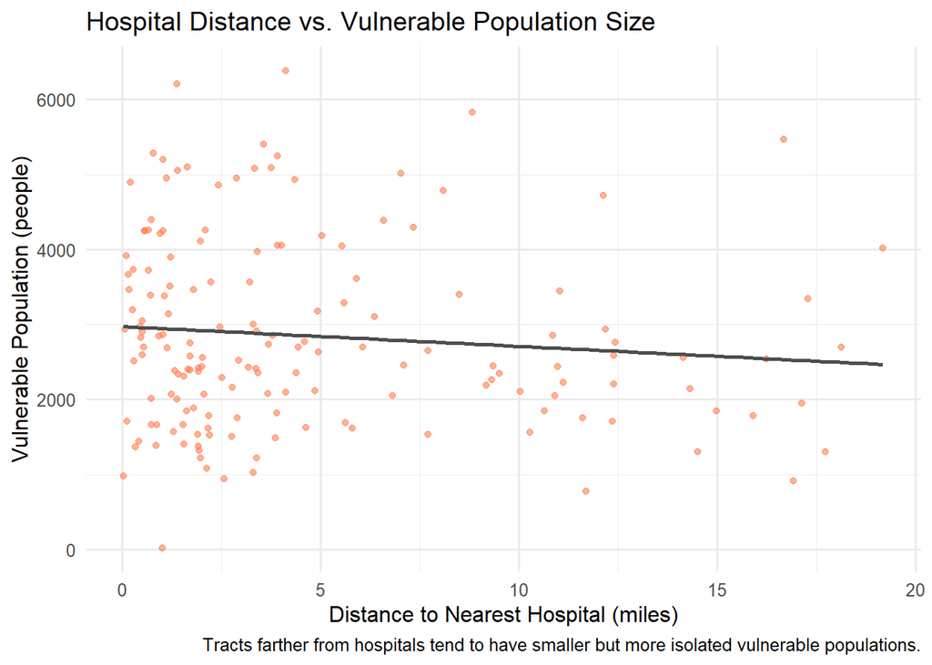

```r
# Create distribution visualization

ggplot(vul_tracts_poly, aes(x = dist_mi, y = total_pop)) +
  geom_point(alpha = 0.6, color = "#FF7F50") +
  geom_smooth(method = "lm", se = FALSE, color = "gray30") +
  labs(
    title = "Hospital Distance vs. Vulnerable Population Size",
    x = "Distance to Nearest Hospital (miles)",
    y = "Vulnerable Population (people)",
    caption = "Tracts farther from hospitals tend to have smaller but more isolated vulnerable populations."
  ) +
  theme_minimal(base_size = 12)
```

**Suggested chart types:** - Histogram or density plot of distances - Box plot comparing distances across regions - Bar chart of underserved tracts by county - Scatter plot of distance vs. vulnerable population size

**Requirements:** - Clear axes labels with units - Appropriate title - Professional formatting - Brief interpretation (1-2 sentences as a caption or in text)

## Part 3: Bring Your Own Data Analysis

Choose your own additional spatial dataset and conduct a supplementary analysis.

### Challenge Options

Choose ONE of the following challenge exercises, or propose your own research question using OpenDataPhilly data (https://opendataphilly.org/datasets/).

**Note these are just loose suggestions to spark ideas - follow or make your own as the data permits and as your ideas evolve. This analysis should include bringing in your own dataset, ensuring the projection/CRS of your layers align and are appropriate for the analysis (not lat/long or geodetic coordinate systems). The analysis portion should include some combination of spatial and attribute operations to answer a relatively straightforward question**

#### Education & Youth Services

**Option A: Educational Desert Analysis** - **Data:** Schools, Libraries, Recreation Centers, Census tracts (child population) - **Question:** “Which neighborhoods lack adequate educational infrastructure for children?” - **Operations:** Buffer schools/libraries (0.5 mile walking distance), identify coverage gaps, overlay with child population density - **Policy relevance:** School district planning, library placement, after-school program siting

**Option B: School Safety Zones** - **Data:** Schools, Crime Incidents, Bike Network - **Question:** “Are school zones safe for walking/biking, or are they crime hotspots?” - **Operations:** Buffer schools (1000ft safety zone), spatial join with crime incidents, assess bike infrastructure coverage - **Policy relevance:** Safe Routes to School programs, crossing guard placement

#### Environmental Justice

**Option C: Green Space Equity** - **Data:** Parks, Street Trees, Census tracts (race/income demographics) - **Question:** “Do low-income and minority neighborhoods have equitable access to green space?” - **Operations:** Buffer parks (10-minute walk = 0.5 mile), calculate tree canopy or park acreage per capita, compare by demographics - **Policy relevance:** Climate resilience, environmental justice, urban forestry investment —

#### Public Safety & Justice

**Option D: Crime & Community Resources** - **Data:** Crime Incidents, Recreation Centers, Libraries, Street Lights - **Question:** “Are high-crime areas underserved by community resources?” - **Operations:** Aggregate crime counts to census tracts or neighborhoods, count community resources per area, spatial correlation analysis - **Policy relevance:** Community investment, violence prevention strategies —

#### Infrastructure & Services

**Option E: Polling Place Accessibility** - **Data:** Polling Places, SEPTA stops, Census tracts (elderly population, disability rates) - **Question:** “Are polling places accessible for elderly and disabled voters?” - **Operations:** Buffer polling places and transit stops, identify vulnerable populations, find areas lacking access - **Policy relevance:** Voting rights, election infrastructure, ADA compliance

#### Health & Wellness

**Option F: Recreation & Population Health** - **Data:** Recreation Centers, Playgrounds, Parks, Census tracts (demographics) - **Question:** “Is lack of recreation access associated with vulnerable populations?” - **Operations:** Calculate recreation facilities per capita by neighborhood, buffer facilities for walking access, overlay with demographic indicators - **Policy relevance:** Public health investment, recreation programming, obesity prevention

#### Emergency Services

**Option G: EMS Response Coverage** - **Data:** Fire Stations, EMS stations, Population density, High-rise buildings - **Question:** “Are population-dense areas adequately covered by emergency services?” - **Operations:** Create service area buffers (5-minute drive = ~2 miles), assess population coverage, identify gaps in high-density areas - **Policy relevance:** Emergency preparedness, station siting decisions

#### Arts & Culture

**Option H: Cultural Asset Distribution** - **Data:** Public Art, Museums, Historic sites/markers, Neighborhoods - **Question:** “Do all neighborhoods have equitable access to cultural amenities?” - **Operations:** Count cultural assets per neighborhood, normalize by population, compare distribution across demographic groups - **Policy relevance:** Cultural equity, tourism, quality of life, neighborhood identity

### Data Sources

**OpenDataPhilly:** https://opendataphilly.org/datasets/ - Most datasets available as GeoJSON, Shapefile, or CSV with coordinates - Always check the Metadata for a data dictionary of the fields.

**Additional Sources:** - **Pennsylvania Open Data:** https://data.pa.gov/ - **Census Bureau (via tidycensus):** Demographics, economic indicators, commute patterns - **TIGER/Line (via tigris):** Geographic boundaries

### Recommended Starting Points

**If you’re feeling confident:** Choose an advanced challenge with multiple data layers. **If you are a beginner, choose something more manageable that helps you understand the basics**

**If you have a different idea:** Propose your own question! Just make sure: - You can access the spatial data - You can perform at least 2 spatial operations

### Your Analysis

**Your Task:**

1. **Find and load additional data**
   - Document your data source
   - Check and standardize the CRS
   - Provide basic summary statistics

[figure not shown]

```r
# Load your additional dataset

phi_school <- read_csv("data_2/PaSchoolDistricts2024_03/2025-2026 Master School List (20251001).csv")
phi_crime <- read_csv("data_2/PaSchoolDistricts2024_03/incidents_part1_part2.csv")
bike <- st_read("data_2/PaSchoolDistricts2024_03/Bike_Network.shp")
city_limit <- st_read("data_2/PaSchoolDistricts2024_03/City_Limits.geojson")
phi_school <- phi_school %>%
  separate(`GPS Location`, into = c("lat", "lng"), sep = ",") %>%
  mutate(
    lat = as.numeric(lat),
    lng = as.numeric(lng)
  )
phi_crime <- phi_crime %>% drop_na(lng, lat)

st_school <- st_as_sf(phi_school, coords = c("lng", "lat"), crs = 4326)
st_crime <- st_as_sf(phi_crime, coords = c("lng", "lat"), crs = 4326)

target_crs <- 26918

st_school <- st_transform(st_school, crs = target_crs)
st_crime  <- st_transform(st_crime,  crs = target_crs)
bike       <- st_transform(bike, crs = target_crs)
city_limit <- st_transform(city_limit, crs = target_crs)

ggplot() +
  geom_sf(data = city_limit, fill = "grey95", color = "grey60", size = 0.4) +
  geom_sf(data = bike, color = "#2b83ba", size = 0.5) +
  geom_sf(data = st_school, color = "coral", shape = 16, size = 1.2) +
  labs(
    title = "Philadelphia Schools, Crime Incidents, and Bike Network",
    caption = "Source: OpenDataPhilly"
  ) +
  theme_void()
```

**Questions to answer:** - What dataset did you choose and why?

I choose School List of Philadelphia, Crime Incidents of Philadelphia and Bike Networks. I choose these data because it’s a question directly related to urban safety and equitable access for students. - What is the data source and date?

The data is from “opendataphilly.org” and it is the data of 2025. (date of bike network data is unknown) - How many features does it contain?

School List contains 1:Administrative info 2:Contact info 3:Location Crime Incident contains 1:Time 2:Location 3:Crime category Bike Networks contains 1:Name 2:road info(type,length,location) - What CRS is it in? Did you need to transform it?

They are all in EPSG:4326 (WGS84). Yes I need to transform them into another CRS(EPSG:26918) which is more accurate locally.

2. **Pose a research question**

Write a clear research statement that your analysis will answer.

Are schools located in high-crime areas also underserved by safe biking and walking infrastructure? **Examples:** - “Do vulnerable tracts have adequate public transit access to hospitals?” - “Are EMS stations appropriately located near vulnerable populations?” - “Do areas with low vehicle access have worse hospital access?”

3. **Conduct spatial analysis**

Use at least TWO spatial operations to answer your research question.

**Required operations (choose 2+):** - Buffers - Spatial joins - Spatial filtering with predicates - Distance calculations - Intersections or unions - Point-in-polygon aggregation

**Your Task:**

```r
# Your spatial analysis

st_school <- st_school %>%
  rename(Publication_Name = `Publication Name`)
school_buffers <- st_buffer(st_school, dist = 305)  # 1000 ft ≈ 305 m

crime_in_buffer <- st_join(st_crime, school_buffers, join = st_within)

crime_summary <- crime_in_buffer %>%
  st_drop_geometry() %>%
  group_by(Publication_Name) %>%
  summarise(crime_n = n())

# Spatial intersection: calculate total length of bike network inside each buffer
bike_in_buffer <- st_intersection(bike, school_buffers)

bike_summary <- bike_in_buffer %>%
  group_by(Publication_Name) %>%
  summarise(bike_length_m = sum(st_length(geometry))) %>%
  mutate(bike_length_mi = set_units(bike_length_m, "mi"))

# Combine results into a single summary table
school_safety <- school_buffers %>%
  left_join(st_drop_geometry(crime_summary), by = "Publication_Name") %>%
  left_join(st_drop_geometry(bike_summary),  by = "Publication_Name") %>%
  mutate(
    crime_n = replace_na(crime_n, 0),
    bike_length_mi = replace_na(as.numeric(bike_length_mi), 0),
    safety_index = crime_n / (bike_length_mi + 0.1)
  )

# Summary statistics
summary_stats <- school_safety %>%
  st_drop_geometry() %>%
  summarise(
    mean_crime = mean(crime_n),
    mean_bike = mean(as.numeric(bike_length_mi)),
    high_crime_schools = sum(crime_n > mean_crime),
    low_bike_schools = sum(as.numeric(bike_length_mi) < mean_bike)
  )

print(summary_stats)
```

```
# A tibble: 1 × 4
  mean_crime mean_bike high_crime_schools low_bike_schools
       <dbl>     <dbl>              <int>            <int>
1       183.     0.430                135              203
```

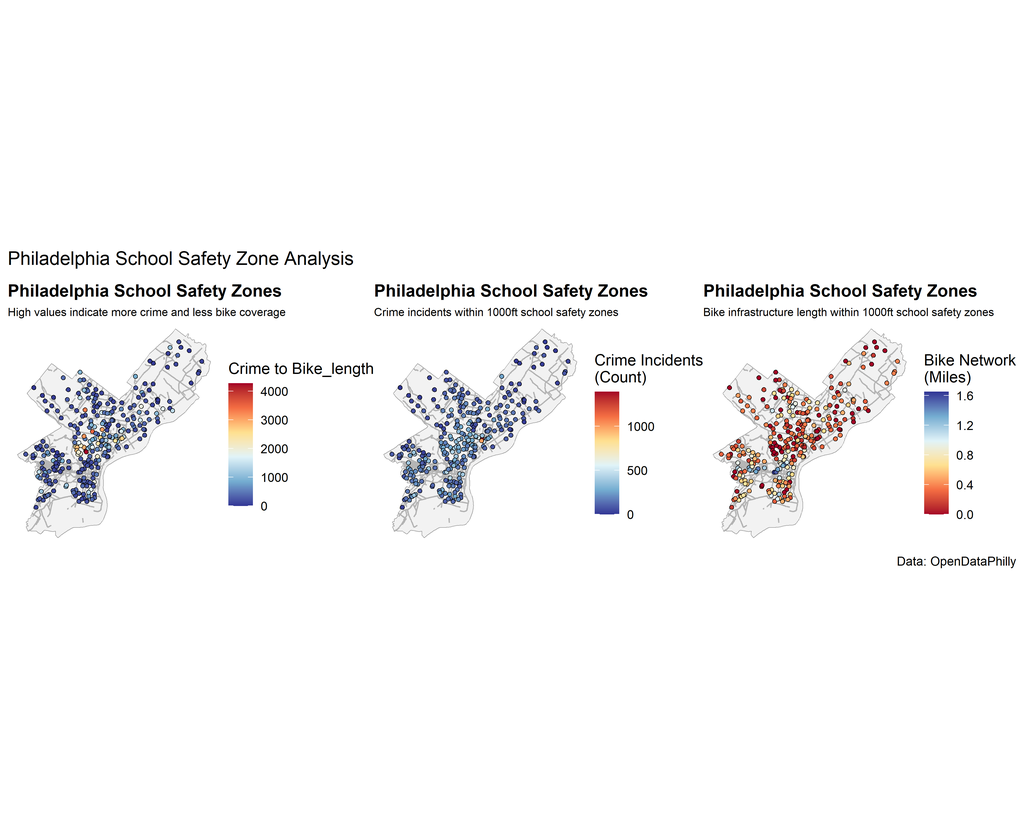

```r
# Visualization: highlight high-crime, low-bike schools
p1 <- ggplot() +
  geom_sf(data = city_limit, fill = "grey95", color = "grey60") +
  geom_sf(data = bike, color = "grey70", size = 0.2) +
  geom_sf(
    data = school_safety,
    aes(fill = safety_index),
    shape = 21, color = "black", size = 2
  ) +
  scale_fill_gradientn(
    colors = c(
      "#313695",
      "#74add1",
      "#e0f3f8",
      "#fee090",
      "#f46d43",
      "#a50026"
    ),
    name = "Crime to Bike_length"
  ) +

  labs(
    title = "Philadelphia School Safety Zones",
    subtitle = "High values indicate more crime and less bike coverage",
  ) +

  theme_void() +
  theme(
    plot.title = element_text(face = "bold", size = 12),
    plot.subtitle = element_text(size = 8),
    legend.position = "right"
  )

p2 <- ggplot() +
  geom_sf(data = city_limit, fill = "grey95", color = "grey60") +
  geom_sf(data = bike, color = "grey70", size = 0.4) +
  geom_sf(
    data = school_safety,
    aes(fill = crime_n),
    shape = 21, color = "black", size = 2
  ) +
  scale_fill_gradientn(
    colors = c(
      "#313695",
      "#74add1",
      "#e0f3f8",
      "#fee090",
      "#f46d43",
      "#a50026"
    ),
    name = "Crime Incidents\n(Count)"
  ) +
  labs(
    title = "Philadelphia School Safety Zones",
    subtitle = "Crime incidents within 1000ft school safety zones",
  ) +
  theme_void() +
  theme(
    plot.title = element_text(face = "bold", size = 12),
    plot.subtitle = element_text(size = 8),
    legend.position = "right"
  )

p3 <- ggplot() +
  geom_sf(data = city_limit, fill = "grey95", color = "grey60") +
  geom_sf(data = bike, color = "grey70", size = 0.4) +
  geom_sf(
    data = school_safety,
    aes(fill = bike_length_mi),
    shape = 21, color = "black", size = 2
  ) +
  scale_fill_gradientn(
    colors = c(
      "#a50026",
      "#f46d43",
      "#fee090",
      "#e0f3f8",
      "#74add1",
      "#313695"
    ),
    name = "Bike Network\n(Miles)"
  ) +
  labs(
    title = "Philadelphia School Safety Zones",
    subtitle = "Bike infrastructure length within 1000ft school safety zones",
  ) +
  theme_void() +
  theme(
    plot.title = element_text(face = "bold", size = 12),
    plot.subtitle = element_text(size = 8),
    legend.position = "right"
  )

(p1 | p2 | p3) +
  plot_annotation(
    title = "Philadelphia School Safety Zone Analysis",
    caption = "Data: OpenDataPhilly"
  )
```

**Analysis requirements:** - Clear code comments explaining each step - Appropriate CRS transformations - Summary statistics or counts - At least one map showing your findings - Brief interpretation of results (3-5 sentences)

**Your interpretation:**

## Finally - A few comments about your incorporation of feedback!

Take a few moments to clean up your markdown document and then write a line or two or three about how you may have incorporated feedback that you recieved after your first assignment.

## Submission Requirements

**What to submit:**

1. **Rendered HTML document posted to your course portfolio** with all code, outputs, maps, and text
   - Use `embed-resources: true` in YAML so it’s a single file
   - All code should run without errors
   - All maps and charts should display correctly

**File naming:** `LastName_FirstName_Assignment2.html` and `LastName_FirstName_Assignment2.qmd`